# nb_Rodan

```python
# import shap  # package used to calculate Shap values

# Create object that can calculate shap values
# explainer = shap.TreeExplainer(my_model)

# Calculate Shap values
# shap_values = explainer.shap_values(data_for_prediction)
```

**Default params but the n_estimators is set to 100,200, 300, and 500 estimators**

[output not shown]

[output not shown]

**Very Simple Linear Regression**

[output not shown]

```python
def linear_regressor(df_train, df_val, df_test, model_features):

    from sklearn.linear_model import LinearRegression

    start_time = time.time()
    target = ['price_per_sq_m_per_lease_yr_norm']
    X_train =  df_train[model_features].copy()
    X_train = X_train.drop(columns = 'price_per_sq_m_per_lease_yr_norm')
    X_train = X_train.values
    X_test =  df_test[model_features].copy()
    X_test =  X_test.drop(columns = 'price_per_sq_m_per_lease_yr_norm')
    X_test = X_test.values
    X_val =  df_val[model_features].copy()
    X_val = X_val.drop(columns = 'price_per_sq_m_per_lease_yr_norm')
    X_val = X_val.values
    y_train =  df_train[target].values.ravel()
    y_val   =  df_val[target].values.ravel()
    y_test  =  df_test[target].values.ravel()

    regr = LinearRegression()

    regr.fit(X_train, y_train)

    y_pred_train =  regr.predict(X_train)
    y_pred_test  =  regr.predict(X_test)
    y_pred_val   =  regr.predict(X_val)

    print('\n--- Test Set ---')
    print('Mean Absolute Error: ...', mean_absolute_error(y_test, y_pred_test))
    print("Mean Squared Error:.....", mean_squared_error(y_test, y_pred_test))
    print('RMSE: ..................', np.sqrt(mean_squared_error(y_test, y_pred_test)))
    print("Coeff of det (R^2):..... %.5f" % r2_score(y_test, y_pred_test))
    print('\n--- Val Set ---')
    print('Mean Absolute Error: ...', mean_absolute_error(y_val, y_pred_val))
    print("Mean Squared Error:.....", mean_squared_error(y_val, y_pred_val))
    print('RMSE: ..................', np.sqrt(mean_squared_error(y_val, y_pred_val)))
    print("Coeff of det (R^2):..... %.5f" % r2_score(y_val, y_pred_val))
    print('\n--- Train Set ---')
    print('Mean Absolute Error: ...', mean_absolute_error(y_train, y_pred_train))
    print("Mean Squared Error:.....", mean_squared_error(y_train, y_pred_train))
    print('RMSE: ..................', np.sqrt(mean_squared_error(y_train, y_pred_train)))
    print("Coeff of det (R^2):..... %.5f" % r2_score(y_train, y_pred_train))

    print("")
    print(regr.get_params(deep=True))

    print("")

    print(regr.coef_)

    print("")

    print(regr.n_features_in_)

    print("")

    print(regr.intercept_)


linear_regressor(df_train, df_val, df_test,features_to_use_for_baseline_testing_with_random_forest_regressor)
```

```
--- Test Set ---
Mean Absolute Error: ... 8.575572539513338
Mean Squared Error:..... 138.47617318978917
RMSE: .................. 11.76758994823448
Coeff of det (R^2):..... 0.60547

--- Val Set ---
Mean Absolute Error: ... 7.890315577906957
Mean Squared Error:..... 122.55365445040054
RMSE: .................. 11.070395406235521
Coeff of det (R^2):..... 0.69185

--- Train Set ---
Mean Absolute Error: ... 6.173024128875581
Mean Squared Error:..... 71.12744350249591
RMSE: .................. 8.433708763201151
Coeff of det (R^2):..... 0.75920

{'copy_X': True, 'fit_intercept': True, 'n_jobs': None, 'normalize': 'deprecated', 'positive': False}

[-6.99332478e-01  1.24251238e+00 -8.61666553e+10 -3.07327363e+00
  3.69178013e+00 -1.18360684e+01  1.46742480e+01 -1.98491065e+01
  1.92840151e+01  2.48308496e+01 -2.05806192e+01  5.59641816e+00
  4.60098401e+00 -1.19974571e+01 -1.02397439e+01 -1.68882944e+01
  7.92982137e+00 -1.89647258e+08  3.13519405e+01 -1.57859268e+01
 -1.54905834e+01  2.21728614e+01 -2.01699142e+01 -1.63251917e+01
 -5.64856332e+00 -9.49521720e+00  8.32349978e+00 -2.09860424e+01
 -1.49990069e+01  8.61666553e+10  1.72333311e+11  2.58499966e+11
  3.44666621e+11  3.44666621e+11  3.44666621e+11]

35

86166655412.58768
```

**Grid Search Stage I**

```python
def grid_search_model(df_train, df_val, df_test,model_features):

    start_time = time.time()
    target = ['price_per_sq_m_per_lease_yr_norm']
    X_train =  df_train[model_features].copy()
    X_train = X_train.drop(columns = 'price_per_sq_m_per_lease_yr_norm')
    X_train = X_train.values
    X_test =  df_test[model_features].copy()
    X_test =  X_test.drop(columns = 'price_per_sq_m_per_lease_yr_norm')
    X_test = X_test.values
    X_val =  df_val[model_features].copy()
    X_val = X_val.drop(columns = 'price_per_sq_m_per_lease_yr_norm')
    X_val = X_val.values
    y_train =  df_train[target].values.ravel()
    y_val   =  df_val[target].values.ravel()
    y_test  =  df_test[target].values.ravel()

    parameters = {'objective':['reg:squarederror'],
                  'max_depth': [3,4,5],
                  'min_child_weight': [4,5,6],
                  'seed': [42],
                  'reg_lambda': [1],
                  'reg_alpha': [100],
                  'gamma': [9,10,11,12],
                  'subsample': [0.5],
                  'colsample_bytree': [0.5],
                  'n_estimators': [300]}

    regr = RandomForestRegressor(n_jobs=-1)

    r_grid = GridSearchCV(regr
                            param_grid=parameters,
                            cv = 3,
                            scoring="r2",
                            n_jobs = -1,
                            verbose=1
                         )

    r_grid.fit(X_train, y_train)

    print(r_grid.best_score_)

    print(r_grid.best_params_)

    print("\n\n--- %s seconds ---" % round((time.time() - start_time)))

grid_search_model(df_train, df_val, df_test,features_to_use_for_baseline_testing_with_random_forest_regressor)
```

```python
def QRF(df_train, df_val, df_test,model_features, i_n_est):

    start_time = time.time()
    from sklearn.ensemble import RandomForestRegressor
    target = ['price_per_sq_m_per_lease_yr_norm']  # predict this !
    X_train =  df_train[model_features].copy()
    X_train = X_train.drop(columns = 'price_per_sq_m_per_lease_yr_norm')
    X_train = X_train.values
    X_test =  df_test[model_features].copy()
    X_test =  X_test.drop(columns = 'price_per_sq_m_per_lease_yr_norm')
    X_test = X_test.values
    X_val =  df_val[model_features].copy()
    X_val = X_val.drop(columns = 'price_per_sq_m_per_lease_yr_norm')
    X_val = X_val.values
    y_train =  df_train[target].values.ravel()
    y_val   =  df_val[target].values.ravel()
    y_test  =  df_test[target].values.ravel()

    print('\nNumber of estimators:  ', i_n_est)

    regr = RandomForestRegressor(n_estimators=i_n_est)

    regr.fit(X_train, y_train)

    y_pred_train =  regr.predict(X_train)
    y_pred_test  =  regr.predict(X_test)
    y_pred_val   =  regr.predict(X_val)

    print('\n--- Test Set ---')
    print('Mean Absolute Error: ...', mean_absolute_error(y_test, y_pred_test))
    print("Mean Squared Error:.....", mean_squared_error(y_test, y_pred_test))
    print('RMSE: ..................', np.sqrt(mean_squared_error(y_test, y_pred_test)))
    print("Coeff of det (R^2):..... %.5f" % r2_score(y_test, y_pred_test))

    print('\n--- Val Set ---')
    print('Mean Absolute Error: ...', mean_absolute_error(y_val, y_pred_val))
    print("Mean Squared Error:..... " % mean_squared_error(y_val, y_pred_val))
    print('RMSE: ..................', np.sqrt(mean_squared_error(y_val, y_pred_val)))
    print("Coeff of det (R^2):..... %.5f" % r2_score(y_val, y_pred_val))

    print('\n--- Train Set ---')
    print('Mean Absolute Error: ...', mean_absolute_error(y_train, y_pred_train))
    print("Mean Squared Error:.....", mean_squared_error(y_train, y_pred_train))
    print('RMSE: ..................', np.sqrt(mean_squared_error(y_train, y_pred_train)))
    print("Coeff of det (R^2):..... %.5f" % r2_score(y_train, y_pred_train))

    print('\nModel Hyperparameters Definitions:')

    pprint(regr.get_params(deep=True))

    print("\n--- %s seconds ---" % round((time.time() - start_time)))

for est in [100,200,300,500]:
    QRF(df_train, df_val, df_test,features_to_use_for_baseline_testing_with_random_forest_regressor, est)
```

[output not shown]

[output cut: 105 more lines]

```
 'max_features': 'auto',
 'max_leaf_nodes': None,
 'max_samples': None,
 'min_impurity_decrease': 0.0,
 'min_samples_leaf': 1,
 'min_samples_split': 2,
 'min_weight_fraction_leaf': 0.0,
 'n_estimators': 500,
 'n_jobs': None,
 'oob_score': False,
 'random_state': None,
 'verbose': 0,
 'warm_start': False}

--- 292 seconds ---
```

```python
def grid_search_model(df_train, df_val, df_test,model_features):

    start_time = time.time()
    target = ['price_per_sq_m_per_lease_yr_norm']
    X_train =  df_train[model_features].copy()
    X_train = X_train.drop(columns = 'price_per_sq_m_per_lease_yr_norm')
    X_train = X_train.values
    X_test =  df_test[model_features].copy()
    X_test =  X_test.drop(columns = 'price_per_sq_m_per_lease_yr_norm')
    X_test = X_test.values
    X_val =  df_val[model_features].copy()
    X_val = X_val.drop(columns = 'price_per_sq_m_per_lease_yr_norm')
    X_val = X_val.values
    y_train =  df_train[target].values.ravel()
    y_val   =  df_val[target].values.ravel()
    y_test  =  df_test[target].values.ravel()

    parameters = {
                  'objective':['reg:squarederror'],
                  'max_depth': [3,4,5],
                  'min_child_weight': [4,5,6],
                  'seed': [42],
                  'reg_lambda': [1],
                  'reg_alpha': [100],
                  'gamma': [9,10,11,12],
                  'subsample': [0.5],
                  'colsample_bytree': [0.5],
                  'n_estimators': [300]}

    regr = RandomForestRegressor(n_jobs=-1)

    r_grid = GridSearchCV(regr
                            param_grid=parameters,
                            cv = 3,
                            scoring="r2",
                            n_jobs = -1,
                            verbose=1
                         )

    r_grid.fit(X_train, y_train)

    print(r_grid.best_score_)

    print(r_grid.best_params_)

    print("\n\n--- %s seconds ---" % round((time.time() - start_time)))

grid_search_model(df_train, df_val, df_test,features_to_use_for_baseline_testing_with_random_forest_regressor)
```

```python
#     # print("Mean Absolute Error: ... %.2f" %  mean_absolute_error(y_test, y_pred_test))
#     # print("Mean Squared Error:..... %.2f" %  mean_squared_error(y_test, y_pred_test))
#     # print('RMSE: .................. %.2f' %  np.sqrt(mean_squared_error(y_test, y_pred_test)))
#     print("Test R^2:...... %.5f" %  r2_score(y_test, y_pred_test))
#     # print('--- Val Set ---')
#     # print('Mean Absolute Error: ... %.2f' %  mean_absolute_error(y_val, y_pred_val))
#     # print("Mean Squared Error:..... %.2f" %  mean_squared_error(y_val, y_pred_val))
#     # print('RMSE: .................. %.2f' %  np.sqrt(mean_squared_error(y_val, y_pred_val)))
#     print("Val R^2:....... %.5f" %  r2_score(y_val, y_pred_val))
#     # print('\n--- Train Set ---')
#     # print('Mean Absolute Error: ... %.2f' %  mean_absolute_error(y_train, y_pred_train))
#     # print("Mean Squared Error:..... %.2f" %  mean_squared_error(y_train, y_pred_train))
#     # print('RMSE: .................. %.2f' %  np.sqrt(mean_squared_error(y_train, y_pred_train)))
#     print("Train R^2:..... %.5f" %  r2_score(y_train, y_pred_train))
```

# DELETE

```python
def QRF(df_train, df_val, df_test,model_features):

    start_time = time.time()
    target = ['price_per_sq_m_per_lease_yr_norm']  # predict this !
    X_train =  df_train[model_features].copy()
    X_train = X_train.drop(columns = 'price_per_sq_m_per_lease_yr_norm')
    X_train = X_train.values
    X_test =  df_test[model_features].copy()
    X_test =  X_test.drop(columns = 'price_per_sq_m_per_lease_yr_norm')
    X_test = X_test.values
    X_val =  df_val[model_features].copy()
    X_val = X_val.drop(columns = 'price_per_sq_m_per_lease_yr_norm')
    X_val = X_val.values
    y_train =  df_train[target].values.ravel()
    y_val   =  df_val[target].values.ravel()
    y_test  =  df_test[target].values.ravel()

    xg = xgb.XGBRegressor()

    xg.fit(X_train, y_train)

    y_pred_train =  xg.predict(X_train)
    y_pred_test  =  xg.predict(X_test)
    y_pred_val   =  xg.predict(X_val)

    print('\n--- Test Set ---')
    print('Mean Absolute Error: ...', mean_absolute_error(y_test, y_pred_test))
    print("Mean Squared Error:..... %.3f" % mean_squared_error(y_test, y_pred_test))
    print('RMSE: ..................', np.sqrt(mean_squared_error(y_test, y_pred_test)))
    print("Coeff of det (R^2):..... %.3f" % r2_score(y_test, y_pred_test))
    print('\n--- Val Set ---')
    print('Mean Absolute Error: ...', mean_absolute_error(y_val, y_pred_val))
    print("Mean Squared Error:..... %.3f" % mean_squared_error(y_val, y_pred_val))
    print('RMSE: ..................', np.sqrt(mean_squared_error(y_val, y_pred_val)))
    print("Coeff of det (R^2):..... %.3f" % r2_score(y_val, y_pred_val))
    print('\n--- Train Set ---')
    print('Mean Absolute Error: ...', mean_absolute_error(y_train, y_pred_train))
    print("Mean Squared Error:..... %.3f" % mean_squared_error(y_train, y_pred_train))
    print('RMSE: ..................', np.sqrt(mean_squared_error(y_train, y_pred_train)))
    print("Coeff of det (R^2):..... %.3f" % r2_score(y_train, y_pred_train))
    print('\nModel Hyperparameters Definitions:')
    pprint(xg.get_params())
    print(xg.get_xgb_params())

    print("\n--- %s seconds ---" % round((time.time() - start_time)))

QRF(df_train, df_val, df_test,features_to_use_from_MM)
```

```
--- Test Set ---
Mean Absolute Error: ... 7.486478949499887
Mean Squared Error:..... 98.396
RMSE: .................. 9.919455082083461
Coeff of det (R^2):..... 0.720

--- Val Set ---
Mean Absolute Error: ... 6.199748722711161
Mean Squared Error:..... 71.647
RMSE: .................. 8.464438603067821
Coeff of det (R^2):..... 0.820

--- Train Set ---
Mean Absolute Error: ... 3.801612508552019
Mean Squared Error:..... 27.006
RMSE: .................. 5.196763958527483
Coeff of det (R^2):..... 0.909

Model Hyperparameters Definitions:
{'base_score': 0.5,
 'booster': 'gbtree',
 'callbacks': None,
 'colsample_bylevel': 1,
 'colsample_bynode': 1,
 'colsample_bytree': 1,
 'early_stopping_rounds': None,
 'enable_categorical': False,
 'eval_metric': None,
 'gamma': 0,
 'gpu_id': -1,
 'grow_policy': 'depthwise',
 'importance_type': None,
 'interaction_constraints': '',
 'learning_rate': 0.300000012,
 'max_bin': 256,
 'max_cat_to_onehot': 4,
 'max_delta_step': 0,
 'max_depth': 6,
 'max_leaves': 0,
 'min_child_weight': 1,
 'missing': nan,
 'monotone_constraints': '()',
 'n_estimators': 100,
 'n_jobs': 0,
 'num_parallel_tree': 1,
 'objective': 'reg:squarederror',
 'predictor': 'auto',
 'random_state': 0,
 'reg_alpha': 0,
 'reg_lambda': 1,
 'sampling_method': 'uniform',
 'scale_pos_weight': 1,
 'subsample': 1,
 'tree_method': 'exact',
 'validate_parameters': 1,
 'verbosity': None}
{'objective': 'reg:squarederror', 'base_score': 0.5, 'booster': 'gbtree', 'colsample_bylevel': 1, 'colsample_bynode': 1, 'colsample_bytree': 1, 'eval_metric': None, 'gamma': 0, 'gpu_id': -1, 'grow_policy': 'depthwise', 'interaction_constraints': '', 'learning_rate': 0.300000012, 'max_bin': 256, 'max…

--- 83 seconds ---
```

```python
#  Objective function ............. reg:squarederror
#  Note ........................... objective will run on GPU
#  Metric (evaluation) function ...

def QRF(df_train, df_val, df_test,model_features):

    start_time = time.time()
    target = ['price_per_sq_m_per_lease_yr_norm']  # predict this !
    X_train =  df_train[model_features].copy()
    X_train = X_train.drop(columns = 'price_per_sq_m_per_lease_yr_norm')
    X_train = X_train.values
    X_test =  df_test[model_features].copy()
    X_test =  X_test.drop(columns = 'price_per_sq_m_per_lease_yr_norm')
    X_test = X_test.values
    X_val =  df_val[model_features].copy()
    X_val = X_val.drop(columns = 'price_per_sq_m_per_lease_yr_norm')
    X_val = X_val.values
    y_train =  df_train[target].values.ravel()
    y_val   =  df_val[target].values.ravel()
    y_test  =  df_test[target].values.ravel()

    special_comments = "\nNote:  no params at all defined"

    xg = xgb.XGBRegressor(

        # objective='reg:squarederror',

        # max_depth = 5,

        # min_child_weight = 4,

        # gamma = 10,

        # subsample = 0.5,

        # colsample_bytree = 0.5,

        # reg_alpha = 100,

        # reg_lambda = 1,

        # n_estimators = 500,

        # learning_rate = 0.1,

        # early_stopping_rounds = 10,

        # validate_parameters = 1, # n_jobs = 1
         #seed=42, random_state=42,
        # tree_method='gpu_hist', gpu_id = 0,
        )


    xg.fit(X_train, y_train)

    y_pred_train =  xg.predict(X_train)
    y_pred_test  =  xg.predict(X_test)
    y_pred_val   =  xg.predict(X_val)

    print('\n--- Test Set ---')
    print('Mean Absolute Error: ...', mean_absolute_error(y_test, y_pred_test))
    print("Mean Squared Error:..... %.3f" % mean_squared_error(y_test, y_pred_test))
    print('RMSE: ..................', np.sqrt(mean_squared_error(y_test, y_pred_test)))
    print("Coeff of det (R^2):..... %.3f" % r2_score(y_test, y_pred_test))
    print('\n--- Val Set ---')
    print('Mean Absolute Error: ...', mean_absolute_error(y_val, y_pred_val))
    print("Mean Squared Error:..... %.3f" % mean_squared_error(y_val, y_pred_val))
    print('RMSE: ..................', np.sqrt(mean_squared_error(y_val, y_pred_val)))
    print("Coeff of det (R^2):..... %.3f" % r2_score(y_val, y_pred_val))
    print('\n--- Train Set ---')
    print('Mean Absolute Error: ...', mean_absolute_error(y_train, y_pred_train))
    print("Mean Squared Error:..... %.3f" % mean_squared_error(y_train, y_pred_train))
    print('RMSE: ..................', np.sqrt(mean_squared_error(y_train, y_pred_train)))
    print("Coeff of det (R^2):..... %.3f" % r2_score(y_train, y_pred_train))
    print('\nModel Hyperparameters Definitions:')
    pprint(xg.get_params())

    print(special_comments)

    print("\n--- %s seconds ---" % round((time.time() - start_time)))

QRF(df_train, df_val, df_test,features_to_use_from_MM)
```

```
--- Test Set ---
Mean Absolute Error: ... 7.486478949499887
Mean Squared Error:..... 98.396
RMSE: .................. 9.919455082083461
Coeff of det (R^2):..... 0.720

--- Val Set ---
Mean Absolute Error: ... 6.199748722711161
Mean Squared Error:..... 71.647
RMSE: .................. 8.464438603067821
Coeff of det (R^2):..... 0.820

--- Train Set ---
Mean Absolute Error: ... 3.801612508552019
Mean Squared Error:..... 27.006
RMSE: .................. 5.196763958527483
Coeff of det (R^2):..... 0.909

Model Hyperparameters Definitions:
{'base_score': 0.5,
 'booster': 'gbtree',
 'callbacks': None,
 'colsample_bylevel': 1,
 'colsample_bynode': 1,
 'colsample_bytree': 1,
 'early_stopping_rounds': None,
 'enable_categorical': False,
 'eval_metric': None,
 'gamma': 0,
 'gpu_id': -1,
 'grow_policy': 'depthwise',
 'importance_type': None,
 'interaction_constraints': '',
 'learning_rate': 0.300000012,
 'max_bin': 256,
 'max_cat_to_onehot': 4,
 'max_delta_step': 0,
 'max_depth': 6,
 'max_leaves': 0,
 'min_child_weight': 1,
 'missing': nan,
 'monotone_constraints': '()',
 'n_estimators': 100,
 'n_jobs': 0,
 'num_parallel_tree': 1,
 'objective': 'reg:squarederror',
 'predictor': 'auto',
 'random_state': 0,
 'reg_alpha': 0,
 'reg_lambda': 1,
 'sampling_method': 'uniform',
 'scale_pos_weight': 1,
 'subsample': 1,
 'tree_method': 'exact',
 'validate_parameters': 1,
 'verbosity': None}

Note:  no params at all defined

--- 72 seconds ---
```

```python
# stop and read this:

# without any tuning:

# --- Test Set ---
# Coeff of det (R^2):..... 0.720

# --- Val Set ---
# Coeff of det (R^2):..... 0.820

# --- Train Set ---
# Coeff of det (R^2):..... 0.909
```

```python
#  Objective function ............. reg:squarederror
#  Note ........................... objective will run on GPU
#  Metric (evaluation) function ...

def QRF(df_train, df_val, df_test,model_features):

    start_time = time.time()
    target = ['price_per_sq_m_per_lease_yr_norm']  # predict this !
    X_train =  df_train[model_features].copy()
    X_train = X_train.drop(columns = 'price_per_sq_m_per_lease_yr_norm')
    X_train = X_train.values
    X_test =  df_test[model_features].copy()
    X_test =  X_test.drop(columns = 'price_per_sq_m_per_lease_yr_norm')
    X_test = X_test.values
    X_val =  df_val[model_features].copy()
    X_val = X_val.drop(columns = 'price_per_sq_m_per_lease_yr_norm')
    X_val = X_val.values
    y_train =  df_train[target].values.ravel()
    y_val   =  df_val[target].values.ravel()
    y_test  =  df_test[target].values.ravel()

    special_comments = "\nNote: adding GPU for speed, n_estimators = 2000"

    xg = xgb.XGBRegressor(

        # objective='reg:squarederror',

        # max_depth = 5,

        # min_child_weight = 4,

        # gamma = 10,

        # subsample = 0.5,

        # colsample_bytree = 0.5,

        # reg_alpha = 100,

        # reg_lambda = 1,

        n_estimators = 2000,

        # learning_rate = 0.1,

        # early_stopping_rounds = 10,

        validate_parameters = 1, # n_jobs = 1
        seed=42, random_state=42,
        tree_method='gpu_hist', gpu_id = 0,
        )


    xg.fit(X_train, y_train)

    y_pred_train =  xg.predict(X_train)
    y_pred_test  =  xg.predict(X_test)
    y_pred_val   =  xg.predict(X_val)

    print('\n--- Test Set ---')
    print('Mean Absolute Error: ...', mean_absolute_error(y_test, y_pred_test))
    print("Mean Squared Error:..... %.3f" % mean_squared_error(y_test, y_pred_test))
    print('RMSE: ..................', np.sqrt(mean_squared_error(y_test, y_pred_test)))
    print("Coeff of det (R^2):..... %.3f" % r2_score(y_test, y_pred_test))
    print('\n--- Val Set ---')
    print('Mean Absolute Error: ...', mean_absolute_error(y_val, y_pred_val))
    print("Mean Squared Error:..... %.3f" % mean_squared_error(y_val, y_pred_val))
    print('RMSE: ..................', np.sqrt(mean_squared_error(y_val, y_pred_val)))
    print("Coeff of det (R^2):..... %.3f" % r2_score(y_val, y_pred_val))
    print('\n--- Train Set ---')
    print('Mean Absolute Error: ...', mean_absolute_error(y_train, y_pred_train))
    print("Mean Squared Error:..... %.3f" % mean_squared_error(y_train, y_pred_train))
    print('RMSE: ..................', np.sqrt(mean_squared_error(y_train, y_pred_train)))
    print("Coeff of det (R^2):..... %.3f" % r2_score(y_train, y_pred_train))
    print('\nModel Hyperparameters Definitions:')
    pprint(xg.get_params())

    print(special_comments)

    print("\n--- %s seconds ---" % round((time.time() - start_time)))

QRF(df_train, df_val, df_test,features_to_use_from_MM)
```

```
--- Test Set ---
Mean Absolute Error: ... 7.638363100257217
Mean Squared Error:..... 101.328
RMSE: .................. 10.066162686918407
Coeff of det (R^2):..... 0.711

--- Val Set ---
Mean Absolute Error: ... 6.242294450482644
Mean Squared Error:..... 73.405
RMSE: .................. 8.567690995986366
Coeff of det (R^2):..... 0.815

--- Train Set ---
Mean Absolute Error: ... 3.2348531934486635
Mean Squared Error:..... 20.694
RMSE: .................. 4.549077297278212
Coeff of det (R^2):..... 0.930

Model Hyperparameters Definitions:
{'base_score': 0.5,
 'booster': 'gbtree',
 'callbacks': None,
 'colsample_bylevel': 1,
 'colsample_bynode': 1,
 'colsample_bytree': 1,
 'early_stopping_rounds': None,
 'enable_categorical': False,
 'eval_metric': None,
 'gamma': 0,
 'gpu_id': 0,
 'grow_policy': 'depthwise',
 'importance_type': None,
 'interaction_constraints': '',
 'learning_rate': 0.300000012,
 'max_bin': 256,
 'max_cat_to_onehot': 4,
 'max_delta_step': 0,
 'max_depth': 6,
 'max_leaves': 0,
 'min_child_weight': 1,
 'missing': nan,
 'monotone_constraints': '()',
 'n_estimators': 2000,
 'n_jobs': 0,
 'num_parallel_tree': 1,
 'objective': 'reg:squarederror',
 'predictor': 'auto',
 'random_state': 42,
 'reg_alpha': 0,
 'reg_lambda': 1,
 'sampling_method': 'uniform',
 'scale_pos_weight': 1,
 'seed': 42,
 'subsample': 1,
 'tree_method': 'gpu_hist',
 'validate_parameters': 1,
 'verbosity': None}

Note: adding GPU for speed, n_estimators = 2000

--- 62 seconds ---
```

```python
#  Objective function ............. reg:squarederror
#  Note ........................... objective will run on GPU
#  Metric (evaluation) function ...

def QRF(df_train, df_val, df_test,model_features):

    start_time = time.time()
    target = ['price_per_sq_m_per_lease_yr_norm']  # predict this !
    X_train =  df_train[model_features].copy()
    X_train = X_train.drop(columns = 'price_per_sq_m_per_lease_yr_norm')
    X_train = X_train.values
    X_test =  df_test[model_features].copy()
    X_test =  X_test.drop(columns = 'price_per_sq_m_per_lease_yr_norm')
    X_test = X_test.values
    X_val =  df_val[model_features].copy()
    X_val = X_val.drop(columns = 'price_per_sq_m_per_lease_yr_norm')
    X_val = X_val.values
    y_train =  df_train[target].values.ravel()
    y_val   =  df_val[target].values.ravel()
    y_test  =  df_test[target].values.ravel()

    special_comments = "\nNote: attempting to replicate what he did"

    #     xg = xgb.XGBRegressor(

    #         # objective='reg:squarederror',

    #         # max_depth = 5,

    #         # min_child_weight = 4,

    #         # gamma = 10,

    #         # subsample = 0.5,

    #         # colsample_bytree = 0.5,

    #         # reg_alpha = 100,

    #         # reg_lambda = 1,

    #         n_estimators = 2000,

    #         # learning_rate = 0.1,

    #         # early_stopping_rounds = 10,

    #         validate_parameters = 1, # n_jobs = 1
    #         seed=42, random_state=42,
    #         tree_method='gpu_hist', gpu_id = 0,
    #         )

    xg = xgb.XGBRegressor(
    objective='reg:squarederror',
    max_depth=3,
    min_child_weight=4,
    gamma = 9,
    subsample=0.5,
    colsample_bytree = 0.5,
    reg_alpha = 100,
    reg_lambda = 1,
    n_estimators=3000,
    learning_rate=0.1,
    nthread=4,
    seed=42,
    tree_method='hist')

    xg.fit(X_train, y_train)

    y_pred_train =  xg.predict(X_train)
    y_pred_test  =  xg.predict(X_test)
    y_pred_val   =  xg.predict(X_val)

    print('\n--- Test Set ---')
    print('Mean Absolute Error: ...', mean_absolute_error(y_test, y_pred_test))
    print("Mean Squared Error:..... %.3f" % mean_squared_error(y_test, y_pred_test))
    print('RMSE: ..................', np.sqrt(mean_squared_error(y_test, y_pred_test)))
    print("Coeff of det (R^2):..... %.3f" % r2_score(y_test, y_pred_test))
    print('\n--- Val Set ---')
    print('Mean Absolute Error: ...', mean_absolute_error(y_val, y_pred_val))
    print("Mean Squared Error:..... %.3f" % mean_squared_error(y_val, y_pred_val))
    print('RMSE: ..................', np.sqrt(mean_squared_error(y_val, y_pred_val)))
    print("Coeff of det (R^2):..... %.3f" % r2_score(y_val, y_pred_val))
    print('\n--- Train Set ---')
    print('Mean Absolute Error: ...', mean_absolute_error(y_train, y_pred_train))
    print("Mean Squared Error:..... %.3f" % mean_squared_error(y_train, y_pred_train))
    print('RMSE: ..................', np.sqrt(mean_squared_error(y_train, y_pred_train)))
    print("Coeff of det (R^2):..... %.3f" % r2_score(y_train, y_pred_train))
    print('\nModel Hyperparameters Definitions:')
    pprint(xg.get_params())

    print(special_comments)

    print("\n--- %s seconds ---" % round((time.time() - start_time)))

QRF(df_train, df_val, df_test,features_to_use_from_MM)
```

```
--- Test Set ---
Mean Absolute Error: ... 7.425380488224853
Mean Squared Error:..... 96.476
RMSE: .................. 9.822229206636852
Coeff of det (R^2):..... 0.725

--- Val Set ---
Mean Absolute Error: ... 6.177023143707141
Mean Squared Error:..... 71.029
RMSE: .................. 8.427858519975128
Coeff of det (R^2):..... 0.821

--- Train Set ---
Mean Absolute Error: ... 3.7720401513075346
Mean Squared Error:..... 26.762
RMSE: .................. 5.173187285426534
Coeff of det (R^2):..... 0.909

Model Hyperparameters Definitions:
{'base_score': 0.5,
 'booster': 'gbtree',
 'callbacks': None,
 'colsample_bylevel': 1,
 'colsample_bynode': 1,
 'colsample_bytree': 0.5,
 'early_stopping_rounds': None,
 'enable_categorical': False,
 'eval_metric': None,
 'gamma': 9,
 'gpu_id': -1,
 'grow_policy': 'depthwise',
 'importance_type': None,
 'interaction_constraints': '',
 'learning_rate': 0.1,
 'max_bin': 256,
 'max_cat_to_onehot': 4,
 'max_delta_step': 0,
 'max_depth': 3,
 'max_leaves': 0,
 'min_child_weight': 4,
 'missing': nan,
 'monotone_constraints': '()',
 'n_estimators': 3000,
 'n_jobs': 4,
 'nthread': 4,
 'num_parallel_tree': 1,
 'objective': 'reg:squarederror',
 'predictor': 'auto',
 'random_state': 42,
 'reg_alpha': 100,
 'reg_lambda': 1,
 'sampling_method': 'uniform',
 'scale_pos_weight': 1,
 'seed': 42,
 'subsample': 0.5,
 'tree_method': 'hist',
 'validate_parameters': 1,
 'verbosity': None}

Note: attempting to replicate what he did

--- 282 seconds ---
```

```python
#  Objective function ............. reg:squarederror
#  Note ........................... objective will run on GPU
#  Metric (evaluation) function ...

def QRF(df_train, df_val, df_test,model_features):

    start_time = time.time()
    target = ['price_per_sq_m_per_lease_yr_norm']  # predict this !
    X_train =  df_train[model_features].copy()
    X_train = X_train.drop(columns = 'price_per_sq_m_per_lease_yr_norm')
    X_train = X_train.values
    X_test =  df_test[model_features].copy()
    X_test =  X_test.drop(columns = 'price_per_sq_m_per_lease_yr_norm')
    X_test = X_test.values
    X_val =  df_val[model_features].copy()
    X_val = X_val.drop(columns = 'price_per_sq_m_per_lease_yr_norm')
    X_val = X_val.values
    y_train =  df_train[target].values.ravel()
    y_val   =  df_val[target].values.ravel()
    y_test  =  df_test[target].values.ravel()

    special_comments = "\nNote: same as him, but using GPU instead, looking for accuracy dec"

    #     xg = xgb.XGBRegressor(

    #         # objective='reg:squarederror',

    #         # max_depth = 5,

    #         # min_child_weight = 4,

    #         # gamma = 10,

    #         # subsample = 0.5,

    #         # colsample_bytree = 0.5,

    #         # reg_alpha = 100,

    #         # reg_lambda = 1,

    #         n_estimators = 2000,

    #         # learning_rate = 0.1,

    #         # early_stopping_rounds = 10,

    #         validate_parameters = 1, # n_jobs = 1
    #         seed=42, random_state=42,
    #         tree_method='gpu_hist', gpu_id = 0,
    #         )

    xg = xgb.XGBRegressor(
    objective='reg:squarederror',
    max_depth=3,
    min_child_weight=4,
    gamma = 9,
    subsample=0.5,
    colsample_bytree = 0.5,
    reg_alpha = 3000,
    reg_lambda = 1,
    n_estimators=3000,
    learning_rate=0.1,
    nthread=4,
    seed=42,
    tree_method='gpu_hist',
    gpu_id=0)

    xg.fit(X_train, y_train)

    y_pred_train =  xg.predict(X_train)
    y_pred_test  =  xg.predict(X_test)
    y_pred_val   =  xg.predict(X_val)

    print('\n--- Test Set ---')

    print("Mean Absolute Error: ... %.2f" %  mean_absolute_error(y_test, y_pred_test))
    print("Mean Squared Error:..... %.2f" %  mean_squared_error(y_test, y_pred_test))
    print('RMSE: .................. %.2f' %  np.sqrt(mean_squared_error(y_test, y_pred_test)))
    print("Coeff of det (R^2):..... %.5f" %  r2_score(y_test, y_pred_test))
    print('\n--- Val Set ---')
    print('Mean Absolute Error: ... %.2f' %  mean_absolute_error(y_val, y_pred_val))
    print("Mean Squared Error:..... %.2f" %  mean_squared_error(y_val, y_pred_val))
    print('RMSE: .................. %.2f' %  np.sqrt(mean_squared_error(y_val, y_pred_val)))
    print("Coeff of det (R^2):..... %.5f" %  r2_score(y_val, y_pred_val))
    print('\n--- Train Set ---')
    print('Mean Absolute Error: ... %.2f' %  mean_absolute_error(y_train, y_pred_train))
    print("Mean Squared Error:..... %.2f" %  mean_squared_error(y_train, y_pred_train))
    print('RMSE: .................. %.2f' %  np.sqrt(mean_squared_error(y_train, y_pred_train)))
    print("Coeff of det (R^2):..... %.5f" %  r2_score(y_train, y_pred_train))
    print('\nModel Hyperparameters Definitions:')

    pprint(xg.get_params())

    print(special_comments)

    print("\n--- %s seconds ---" % round((time.time() - start_time)))

QRF(df_train, df_val, df_test,features_to_use_from_MM)
```

[output not shown]

```python
# STOP:  REMEMBER:  WHEN YOU ARE USING GPU_HIST, IT WILL BE CLOSE BUT NOT
#        THE PRECISE SAME OUTPUT AS IF YOU USED CPU.  THIS IS NORMAL.
#        THEY ARE IN FACT DIFFERENT ALGORITHM IMPLEMENTATIONS...
```

```python
def QRF(df_train, df_val, df_test,model_features):

    start_time = time.time()
    target = ['price_per_sq_m_per_lease_yr_norm']  # predict this !
    X_train =  df_train[model_features].copy()
    X_train = X_train.drop(columns = 'price_per_sq_m_per_lease_yr_norm')
    X_train = X_train.values
    X_test =  df_test[model_features].copy()
    X_test =  X_test.drop(columns = 'price_per_sq_m_per_lease_yr_norm')
    X_test = X_test.values
    X_val =  df_val[model_features].copy()
    X_val = X_val.drop(columns = 'price_per_sq_m_per_lease_yr_norm')
    X_val = X_val.values
    y_train =  df_train[target].values.ravel()
    y_val   =  df_val[target].values.ravel()
    y_test  =  df_test[target].values.ravel()

    special_comments = "\nGPU-based, Replicating my best hyperparameters, but on his system, to see if matches"


    #     xg = xgb.XGBRegressor(

    #         # objective='reg:squarederror',

    #         # max_depth = 5,

    #         # min_child_weight = 4,

    #         # gamma = 10,

    #         # subsample = 0.5,

    #         # colsample_bytree = 0.5,

    #         # reg_alpha = 100,

    #         # reg_lambda = 1,

    #         n_estimators = 2000,

    #         # learning_rate = 0.1,

    #         # early_stopping_rounds = 10,

    #         validate_parameters = 1, # n_jobs = 1
    #         seed=42, random_state=42,
    #         tree_method='gpu_hist', gpu_id = 0,
    #         )

    # mine to him:

    xg = xgb.XGBRegressor(
    objective='reg:squarederror',
    max_depth=5,
    min_child_weight=4,
    gamma = 10,
    subsample=0.5,
    colsample_bytree = 0.5,
    reg_alpha = 100,
    reg_lambda = 1,
    n_estimators=3000,
    learning_rate=0.1,
    seed=42,
    tree_method='gpu_hist',
    gpu_id = 0)

    xg.fit(X_train, y_train)

    y_pred_train =  xg.predict(X_train)
    y_pred_test  =  xg.predict(X_test)
    y_pred_val   =  xg.predict(X_val)

    print('\n--- Test Set ---')

    print("Mean Absolute Error: ... %.2f" %  mean_absolute_error(y_test, y_pred_test))
    print("Mean Squared Error:..... %.2f" %  mean_squared_error(y_test, y_pred_test))
    print('RMSE: .................. %.2f' %  np.sqrt(mean_squared_error(y_test, y_pred_test)))
    print("Coeff of det (R^2):..... %.5f" %  r2_score(y_test, y_pred_test))
    print('\n--- Val Set ---')
    print('Mean Absolute Error: ... %.2f' %  mean_absolute_error(y_val, y_pred_val))
    print("Mean Squared Error:..... %.2f" %  mean_squared_error(y_val, y_pred_val))
    print('RMSE: .................. %.2f' %  np.sqrt(mean_squared_error(y_val, y_pred_val)))
    print("Coeff of det (R^2):..... %.5f" %  r2_score(y_val, y_pred_val))
    print('\n--- Train Set ---')
    print('Mean Absolute Error: ... %.2f' %  mean_absolute_error(y_train, y_pred_train))
    print("Mean Squared Error:..... %.2f" %  mean_squared_error(y_train, y_pred_train))
    print('RMSE: .................. %.2f' %  np.sqrt(mean_squared_error(y_train, y_pred_train)))
    print("Coeff of det (R^2):..... %.5f" %  r2_score(y_train, y_pred_train))
    print('\nModel Hyperparameters Definitions:')

    pprint(xg.get_params())

    print(special_comments)

    print("\n--- %s seconds ---" % round((time.time() - start_time)))

QRF(df_train, df_val, df_test,features_to_use_from_MM)
```

```
--- Test Set ---
Mean Absolute Error: ... 7.43
Mean Squared Error:..... 96.23
RMSE: .................. 9.81
Coeff of det (R^2):..... 0.72582

--- Val Set ---
Mean Absolute Error: ... 6.14
Mean Squared Error:..... 70.14
RMSE: .................. 8.38
Coeff of det (R^2):..... 0.82363

--- Train Set ---
Mean Absolute Error: ... 3.61
Mean Squared Error:..... 24.67
RMSE: .................. 4.97
Coeff of det (R^2):..... 0.91649

Model Hyperparameters Definitions:
{'base_score': 0.5,
 'booster': 'gbtree',
 'callbacks': None,
 'colsample_bylevel': 1,
 'colsample_bynode': 1,
 'colsample_bytree': 0.5,
 'early_stopping_rounds': None,
 'enable_categorical': False,
 'eval_metric': None,
 'gamma': 10,
 'gpu_id': 0,
 'grow_policy': 'depthwise',
 'importance_type': None,
 'interaction_constraints': '',
 'learning_rate': 0.1,
 'max_bin': 256,
 'max_cat_to_onehot': 4,
 'max_delta_step': 0,
 'max_depth': 5,
 'max_leaves': 0,
 'min_child_weight': 4,
 'missing': nan,
 'monotone_constraints': '()',
 'n_estimators': 3000,
 'n_jobs': 0,
 'num_parallel_tree': 1,
 'objective': 'reg:squarederror',
 'predictor': 'auto',
 'random_state': 42,
 'reg_alpha': 100,
 'reg_lambda': 1,
 'sampling_method': 'uniform',
 'scale_pos_weight': 1,
 'seed': 42,
 'subsample': 0.5,
 'tree_method': 'gpu_hist',
 'validate_parameters': 1,
 'verbosity': None}

GPU-based, Replicating my best hyperparameters, but on his system, to see if matches

--- 64 seconds ---
```

```python
?
```

```python
def QRF(df_train, df_val, df_test,model_features):

    start_time = time.time()
    target = ['price_per_sq_m_per_lease_yr_norm']  # predict this !
    X_train =  df_train[model_features].copy()
    X_train = X_train.drop(columns = 'price_per_sq_m_per_lease_yr_norm')
    X_train = X_train.values
    X_test =  df_test[model_features].copy()
    X_test =  X_test.drop(columns = 'price_per_sq_m_per_lease_yr_norm')
    X_test = X_test.values
    X_val =  df_val[model_features].copy()
    X_val = X_val.drop(columns = 'price_per_sq_m_per_lease_yr_norm')
    X_val = X_val.values
    y_train =  df_train[target].values.ravel()
    y_val   =  df_val[target].values.ravel()
    y_test  =  df_test[target].values.ravel()

    special_comments = "\nReplicating my best hyperparameters, but on his system, to see if matches"


    #     xg = xgb.XGBRegressor(

    #         # objective='reg:squarederror',

    #         # max_depth = 5,

    #         # min_child_weight = 4,

    #         # gamma = 10,

    #         # subsample = 0.5,

    #         # colsample_bytree = 0.5,

    #         # reg_alpha = 100,

    #         # reg_lambda = 1,

    #         n_estimators = 2000,

    #         # learning_rate = 0.1,

    #         # early_stopping_rounds = 10,

    #         validate_parameters = 1, # n_jobs = 1
    #         seed=42, random_state=42,
    #         tree_method='gpu_hist', gpu_id = 0,
    #         )

    # mine to him:

    xg = xgb.XGBRegressor(
    objective='reg:squarederror',
    max_depth=5,
    min_child_weight=4,
    gamma = 10,
    subsample=0.5,
    colsample_bytree = 0.5,
    reg_alpha = 100,
    reg_lambda = 1,
    n_estimators=3000,
    learning_rate=0.1,
    seed=42,
    tree_method='hist',
    nthread=23)

    xg.fit(X_train, y_train)

    y_pred_train =  xg.predict(X_train)
    y_pred_test  =  xg.predict(X_test)
    y_pred_val   =  xg.predict(X_val)

    print('\n--- Test Set ---')

    print("Mean Absolute Error: ... %.2f" %  mean_absolute_error(y_test, y_pred_test))
    print("Mean Squared Error:..... %.2f" %  mean_squared_error(y_test, y_pred_test))
    print('RMSE: .................. %.2f' %  np.sqrt(mean_squared_error(y_test, y_pred_test)))
    print("Coeff of det (R^2):..... %.5f" %  r2_score(y_test, y_pred_test))
    print('\n--- Val Set ---')
    print('Mean Absolute Error: ... %.2f' %  mean_absolute_error(y_val, y_pred_val))
    print("Mean Squared Error:..... %.2f" %  mean_squared_error(y_val, y_pred_val))
    print('RMSE: .................. %.2f' %  np.sqrt(mean_squared_error(y_val, y_pred_val)))
    print("Coeff of det (R^2):..... %.5f" %  r2_score(y_val, y_pred_val))
    print('\n--- Train Set ---')
    print('Mean Absolute Error: ... %.2f' %  mean_absolute_error(y_train, y_pred_train))
    print("Mean Squared Error:..... %.2f" %  mean_squared_error(y_train, y_pred_train))
    print('RMSE: .................. %.2f' %  np.sqrt(mean_squared_error(y_train, y_pred_train)))
    print("Coeff of det (R^2):..... %.5f" %  r2_score(y_train, y_pred_train))
    print('\nModel Hyperparameters Definitions:')

    pprint(xg.get_params())

    print(special_comments)

    print("\n--- %s seconds ---" % round((time.time() - start_time)))

QRF(df_train, df_val, df_test,features_to_use_from_MM)
```

```
--- Test Set ---
Mean Absolute Error: ... 7.46
Mean Squared Error:..... 96.94
RMSE: .................. 9.85
Coeff of det (R^2):..... 0.72382

--- Val Set ---
Mean Absolute Error: ... 6.14
Mean Squared Error:..... 70.28
RMSE: .................. 8.38
Coeff of det (R^2):..... 0.82329

--- Train Set ---
Mean Absolute Error: ... 3.60
Mean Squared Error:..... 24.63
RMSE: .................. 4.96
Coeff of det (R^2):..... 0.91662

Model Hyperparameters Definitions:
{'base_score': 0.5,
 'booster': 'gbtree',
 'callbacks': None,
 'colsample_bylevel': 1,
 'colsample_bynode': 1,
 'colsample_bytree': 0.5,
 'early_stopping_rounds': None,
 'enable_categorical': False,
 'eval_metric': None,
 'gamma': 10,
 'gpu_id': -1,
 'grow_policy': 'depthwise',
 'importance_type': None,
 'interaction_constraints': '',
 'learning_rate': 0.1,
 'max_bin': 256,
 'max_cat_to_onehot': 4,
 'max_delta_step': 0,
 'max_depth': 5,
 'max_leaves': 0,
 'min_child_weight': 4,
 'missing': nan,
 'monotone_constraints': '()',
 'n_estimators': 3000,
 'n_jobs': 23,
 'nthread': 23,
 'num_parallel_tree': 1,
 'objective': 'reg:squarederror',
 'predictor': 'auto',
 'random_state': 42,
 'reg_alpha': 100,
 'reg_lambda': 1,
 'sampling_method': 'uniform',
 'scale_pos_weight': 1,
 'seed': 42,
 'subsample': 0.5,
 'tree_method': 'hist',
 'validate_parameters': 1,
 'verbosity': None}

Replicating my best hyperparameters, but on his system, to see if matches

--- 291 seconds ---
```

# --- STOP AND READ CAREFULLY FROM HERE ---

## Its time to sweep...

### Experiment: Iterating over max_depth

> Iterating over max_depth (leveraring GPU speed) !

```python
print('Iterating over max_depth for understanding...')
start_time = time.time()

def QRF_i(df_train, df_val, df_test,model_features, input_max_depth):
    start_time = time.time()
    target = ['price_per_sq_m_per_lease_yr_norm']  # predict this !
    X_train =  df_train[model_features].copy()
    X_train = X_train.drop(columns = 'price_per_sq_m_per_lease_yr_norm')
    X_train = X_train.values
    X_test =  df_test[model_features].copy()
    X_test =  X_test.drop(columns = 'price_per_sq_m_per_lease_yr_norm')
    X_test = X_test.values
    X_val =  df_val[model_features].copy()
    X_val = X_val.drop(columns = 'price_per_sq_m_per_lease_yr_norm')
    X_val = X_val.values
    y_train =  df_train[target].values.ravel()
    y_val   =  df_val[target].values.ravel()
    y_test  =  df_test[target].values.ravel()

    xg = xgb.XGBRegressor(
    objective='reg:squarederror',
    max_depth=input_max_depth,
    min_child_weight=4,
    gamma = 10,
    subsample=0.5,
    colsample_bytree = 0.5,
    reg_alpha = 100,
    reg_lambda = 1,
    n_estimators=2000,
    learning_rate=0.15,
    seed=42, tree_method='gpu_hist', gpu_id=0)

    print('MAX DEPTH .......', input_max_depth)

    xg.fit(X_train, y_train)

    y_pred_train =  xg.predict(X_train)
    y_pred_test  =  xg.predict(X_test)
    y_pred_val   =  xg.predict(X_val)

    # print('--- Test Set ---')

    # print("Mean Absolute Error: ... %.2f" %  mean_absolute_error(y_test, y_pred_test))
    # print("Mean Squared Error:..... %.2f" %  mean_squared_error(y_test, y_pred_test))
    # print('RMSE: .................. %.2f' %  np.sqrt(mean_squared_error(y_test, y_pred_test)))
    print("Test R^2:...... %.5f" %  r2_score(y_test, y_pred_test))
    # print('--- Val Set ---')
    # print('Mean Absolute Error: ... %.2f' %  mean_absolute_error(y_val, y_pred_val))
    # print("Mean Squared Error:..... %.2f" %  mean_squared_error(y_val, y_pred_val))
    # print('RMSE: .................. %.2f' %  np.sqrt(mean_squared_error(y_val, y_pred_val)))
    print("Val R^2:....... %.5f" %  r2_score(y_val, y_pred_val))
    # print('\n--- Train Set ---')
    # print('Mean Absolute Error: ... %.2f' %  mean_absolute_error(y_train, y_pred_train))
    # print("Mean Squared Error:..... %.2f" %  mean_squared_error(y_train, y_pred_train))
    # print('RMSE: .................. %.2f' %  np.sqrt(mean_squared_error(y_train, y_pred_train)))
    print("Train R^2:..... %.5f" %  r2_score(y_train, y_pred_train))

    #print('\nModel Hyperparameters Definitions:')

    #pprint(xg.get_params())

    #print(special_comments)

    # print("\n--- %s seconds ---" % round((time.time() - start_time)))

for md in [3,4,5,6,7,8,9, 10, 11]:
    QRF_i(df_train, df_val, df_test,features_to_use_from_MM, md)

print("\n--- %s seconds ---" % round((time.time() - start_time)))
```

```
Iterating over max_depth for understanding...
MAX DEPTH ....... 3
Test R^2:...... 0.72411
Val R^2:....... 0.82155
Train R^2:..... 0.90909
MAX DEPTH ....... 4
Test R^2:...... 0.72445
Val R^2:....... 0.82300
Train R^2:..... 0.91363
MAX DEPTH ....... 5
Test R^2:...... 0.72450
Val R^2:....... 0.82322
Train R^2:..... 0.91638
MAX DEPTH ....... 6
Test R^2:...... 0.72292
Val R^2:....... 0.82304
Train R^2:..... 0.91845
MAX DEPTH ....... 7
Test R^2:...... 0.72368
Val R^2:....... 0.82324
Train R^2:..... 0.92013
MAX DEPTH ....... 8
Test R^2:...... 0.72335
Val R^2:....... 0.82289
Train R^2:..... 0.92146
MAX DEPTH ....... 9
Test R^2:...... 0.71977
Val R^2:....... 0.82209
Train R^2:..... 0.92258
MAX DEPTH ....... 10
Test R^2:...... 0.71890
Val R^2:....... 0.82234
Train R^2:..... 0.92347
MAX DEPTH ....... 11
Test R^2:...... 0.71906
Val R^2:....... 0.82072
Train R^2:..... 0.92434

--- 789 seconds ---
```

[output not shown]

```python
max_depth = [3,4,5,6,7,8,9, 10, 11]

test = [0.72411, 0.72445, 0.72450, 0.72292, 0.72368,
        0.72335, 0.71977, 0.71890, 0.71906]

train = [0.90909, 0.91363, 0.91638, 0.91845,
         0.92013, 0.92146, 0.92258, 0.92347,
         0.92434]

val = [0.82155, 0.82300, 0.82322,
       0.82304, 0.82324, 0.82289,
       0.82209, 0.82234, 0.82072]

df = pd.DataFrame(list(zip(max_depth, train, test, val)),
               columns =['max_depth', "train", "test", "val"])

df
```

|  | max_depth | train | test | val |
| --- | --- | --- | --- | --- |
| 0 | 3 | 0.90909 | 0.72411 | 0.82155 |
| 1 | 4 | 0.91363 | 0.72445 | 0.82300 |
| 2 | 5 | 0.91638 | 0.72450 | 0.82322 |
| 3 | 6 | 0.91845 | 0.72292 | 0.82304 |
| 4 | 7 | 0.92013 | 0.72368 | 0.82324 |
| 5 | 8 | 0.92146 | 0.72335 | 0.82289 |
| 6 | 9 | 0.92258 | 0.71977 | 0.82209 |
| 7 | 10 | 0.92347 | 0.71890 | 0.82234 |
| 8 | 11 | 0.92434 | 0.71906 | 0.82072 |

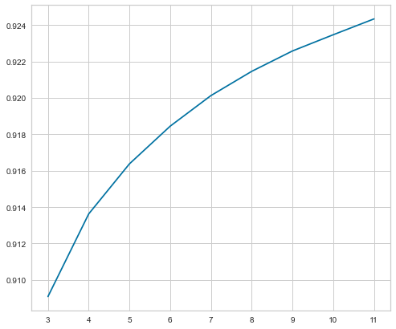

```python
# train
plt.figure(figsize=(8,7))
plt.plot(max_depth, train, label='train')
plt.show();
```

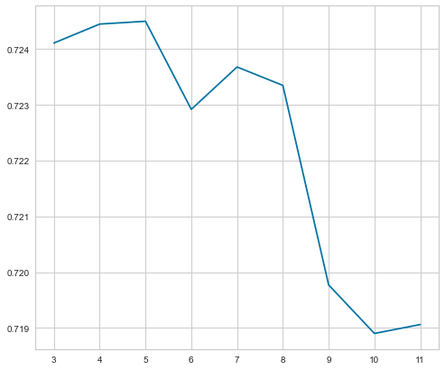

```python
# test
plt.figure(figsize=(8,7))
plt.plot(max_depth, test, label = 'test')
plt.show();
```

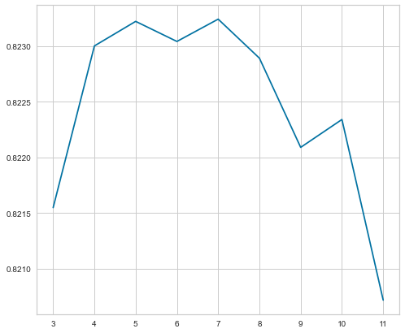

```python
# val
plt.figure(figsize=(8,7))
plt.plot(max_depth, val, label='val')
plt.show();
```

> 5 ?

### Experiment: Iterating over learning rate

> Iterating over learning rate (leveraring GPU speed) !

```python
print('Iterating over learning rate for understanding...')
start_time = time.time()

def QRF_i(df_train, df_val, df_test,model_features, incremental_lr):
    start_time = time.time()
    target = ['price_per_sq_m_per_lease_yr_norm']  # predict this !
    X_train =  df_train[model_features].copy()
    X_train = X_train.drop(columns = 'price_per_sq_m_per_lease_yr_norm')
    X_train = X_train.values
    X_test =  df_test[model_features].copy()
    X_test =  X_test.drop(columns = 'price_per_sq_m_per_lease_yr_norm')
    X_test = X_test.values
    X_val =  df_val[model_features].copy()
    X_val = X_val.drop(columns = 'price_per_sq_m_per_lease_yr_norm')
    X_val = X_val.values
    y_train =  df_train[target].values.ravel()
    y_val   =  df_val[target].values.ravel()
    y_test  =  df_test[target].values.ravel()

    # lock down everything but learning rate...

    xg = xgb.XGBRegressor(
    objective='reg:squarederror',
    max_depth=5,
    min_child_weight=4,
    gamma = 10,
    subsample=0.5,
    colsample_bytree = 0.5,
    reg_alpha = 100,
    reg_lambda = 1,
    n_estimators=2000,
    learning_rate= incremental_lr,
    seed=42, tree_method='gpu_hist', gpu_id=0)

    print('LEARNING RATE .......', incremental_lr)

    xg.fit(X_train, y_train)

    y_pred_train =  xg.predict(X_train)
    y_pred_test  =  xg.predict(X_test)
    y_pred_val   =  xg.predict(X_val)

    # print('--- Test Set ---')

    # print("Mean Absolute Error: ... %.2f" %  mean_absolute_error(y_test, y_pred_test))
    # print("Mean Squared Error:..... %.2f" %  mean_squared_error(y_test, y_pred_test))
    # print('RMSE: .................. %.2f' %  np.sqrt(mean_squared_error(y_test, y_pred_test)))
    print("Test R^2:...... %.5f" %  r2_score(y_test, y_pred_test))
    # print('--- Val Set ---')
    # print('Mean Absolute Error: ... %.2f' %  mean_absolute_error(y_val, y_pred_val))
    # print("Mean Squared Error:..... %.2f" %  mean_squared_error(y_val, y_pred_val))
    # print('RMSE: .................. %.2f' %  np.sqrt(mean_squared_error(y_val, y_pred_val)))
    print("Val R^2:....... %.5f" %  r2_score(y_val, y_pred_val))
    # print('\n--- Train Set ---')
    # print('Mean Absolute Error: ... %.2f' %  mean_absolute_error(y_train, y_pred_train))
    # print("Mean Squared Error:..... %.2f" %  mean_squared_error(y_train, y_pred_train))
    # print('RMSE: .................. %.2f' %  np.sqrt(mean_squared_error(y_train, y_pred_train)))
    print("Train R^2:..... %.5f" %  r2_score(y_train, y_pred_train))

    #print('\nModel Hyperparameters Definitions:')

    #pprint(xg.get_params())

    #print(special_comments)

    # print("\n--- %s seconds ---" % round((time.time() - start_time)))

for ilr in [.10, .11, .12, .13, .14, .15, .16, .17, .18, .19, .20]:
    QRF_i(df_train, df_val, df_test,features_to_use_from_MM, ilr)

print("\n--- %s seconds ---" % round((time.time() - start_time)))
```

```
Iterating over learning rate for understanding...
LEARNING RATE ....... 0.1
Test R^2:...... 0.72566
Val R^2:....... 0.82368
Train R^2:..... 0.91530
LEARNING RATE ....... 0.11
Test R^2:...... 0.72488
Val R^2:....... 0.82348
Train R^2:..... 0.91554
LEARNING RATE ....... 0.12
Test R^2:...... 0.72476
Val R^2:....... 0.82348
Train R^2:..... 0.91579
LEARNING RATE ....... 0.13
Test R^2:...... 0.72389
Val R^2:....... 0.82352
Train R^2:..... 0.91609
LEARNING RATE ....... 0.14
Test R^2:...... 0.72410
Val R^2:....... 0.82360
Train R^2:..... 0.91624
LEARNING RATE ....... 0.15
Test R^2:...... 0.72450
Val R^2:....... 0.82322
Train R^2:..... 0.91638
LEARNING RATE ....... 0.16
Test R^2:...... 0.72220
Val R^2:....... 0.82285
Train R^2:..... 0.91649
LEARNING RATE ....... 0.17
Test R^2:...... 0.72203
Val R^2:....... 0.82259
Train R^2:..... 0.91662
LEARNING RATE ....... 0.18
Test R^2:...... 0.72160
Val R^2:....... 0.82358
Train R^2:..... 0.91667
LEARNING RATE ....... 0.19
Test R^2:...... 0.72200
Val R^2:....... 0.82312
Train R^2:..... 0.91680
LEARNING RATE ....... 0.2
Test R^2:...... 0.72424
Val R^2:....... 0.82271
Train R^2:..... 0.91692

--- 487 seconds ---
```

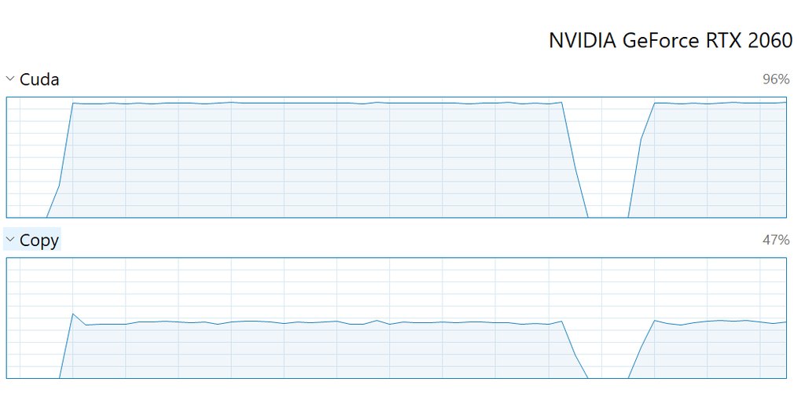

[output not shown]

[output not shown]

```python
learning_rate = [.10, .11, .12, .13, .14, .15, .16, .17, .18, .19, .20]


train = [0.91530,
0.91554,
0.91579,
0.91609,
0.91624,
0.91638,
0.91649,
0.91662,
0.91667,
0.91680,
0.91692]


test = [0.72566,
0.72488,
0.72476,
0.72389,
0.72410,
0.72450,
0.72220,
0.72203,
0.72160,
0.72200,
0.72424]

val = [0.82368,
0.82348,
0.82348,
0.82352,
0.82360,
0.82322,
0.82285,
0.82259,
0.82358,
0.82312,
0.82271]

df = pd.DataFrame(list(zip(learning_rate, train, test, val)),
               columns =['learning_rate', "train", "test", "val"])

df
```

|  | learning_rate | train | test | val |
| --- | --- | --- | --- | --- |
| 0 | 0.10000 | 0.91530 | 0.72566 | 0.82368 |
| 1 | 0.11000 | 0.91554 | 0.72488 | 0.82348 |
| 2 | 0.12000 | 0.91579 | 0.72476 | 0.82348 |
| 3 | 0.13000 | 0.91609 | 0.72389 | 0.82352 |
| 4 | 0.14000 | 0.91624 | 0.72410 | 0.82360 |
| 5 | 0.15000 | 0.91638 | 0.72450 | 0.82322 |
| 6 | 0.16000 | 0.91649 | 0.72220 | 0.82285 |
| 7 | 0.17000 | 0.91662 | 0.72203 | 0.82259 |
| 8 | 0.18000 | 0.91667 | 0.72160 | 0.82358 |
| 9 | 0.19000 | 0.91680 | 0.72200 | 0.82312 |
| 10 | 0.20000 | 0.91692 | 0.72424 | 0.82271 |

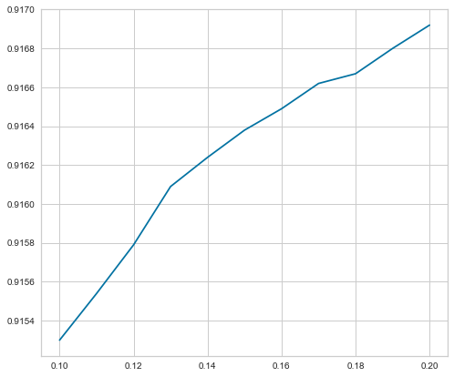

```python
# train
plt.figure(figsize=(8,7))
plt.plot(learning_rate, train, label='train')
plt.show();
```

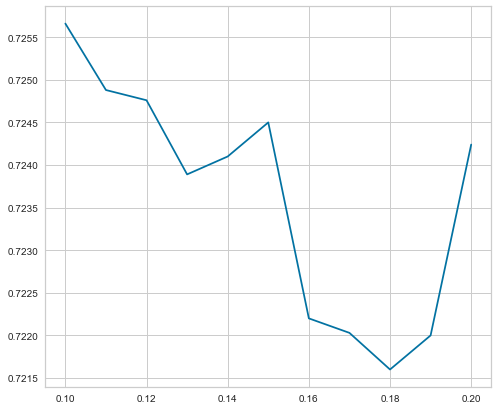

```python
# test
plt.figure(figsize=(8,7))
plt.plot(learning_rate, test, label = 'test')
plt.show();
```

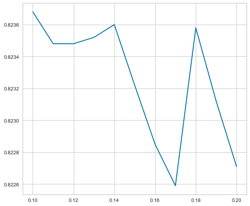

```python
# val
plt.figure(figsize=(8,7))
plt.plot(learning_rate, val, label='val')
plt.show();
```

> 0.10 looks perfect...

```python
print('Iterating over learning rate AGAIN for understanding...')
start_time = time.time()

def QRF_i(df_train, df_val, df_test,model_features, incremental_lr):
    start_time = time.time()
    target = ['price_per_sq_m_per_lease_yr_norm']  # predict this !
    X_train =  df_train[model_features].copy()
    X_train = X_train.drop(columns = 'price_per_sq_m_per_lease_yr_norm')
    X_train = X_train.values
    X_test =  df_test[model_features].copy()
    X_test =  X_test.drop(columns = 'price_per_sq_m_per_lease_yr_norm')
    X_test = X_test.values
    X_val =  df_val[model_features].copy()
    X_val = X_val.drop(columns = 'price_per_sq_m_per_lease_yr_norm')
    X_val = X_val.values
    y_train =  df_train[target].values.ravel()
    y_val   =  df_val[target].values.ravel()
    y_test  =  df_test[target].values.ravel()

    # lock down everything but learning rate...

    xg = xgb.XGBRegressor(
    objective='reg:squarederror',
    max_depth=5,
    min_child_weight=4,
    gamma = 10,
    subsample=0.5,
    colsample_bytree = 0.5,
    reg_alpha = 100,
    reg_lambda = 1,
    n_estimators=2000,
    learning_rate= incremental_lr,
    seed=42, tree_method='gpu_hist', gpu_id=0)

    print('LEARNING RATE .......', incremental_lr)

    xg.fit(X_train, y_train)

    y_pred_train =  xg.predict(X_train)
    y_pred_test  =  xg.predict(X_test)
    y_pred_val   =  xg.predict(X_val)

    # print('--- Test Set ---')

    # print("Mean Absolute Error: ... %.2f" %  mean_absolute_error(y_test, y_pred_test))
    # print("Mean Squared Error:..... %.2f" %  mean_squared_error(y_test, y_pred_test))
    # print('RMSE: .................. %.2f' %  np.sqrt(mean_squared_error(y_test, y_pred_test)))
    print("Test R^2:...... %.5f" %  r2_score(y_test, y_pred_test))
    # print('--- Val Set ---')
    # print('Mean Absolute Error: ... %.2f' %  mean_absolute_error(y_val, y_pred_val))
    # print("Mean Squared Error:..... %.2f" %  mean_squared_error(y_val, y_pred_val))
    # print('RMSE: .................. %.2f' %  np.sqrt(mean_squared_error(y_val, y_pred_val)))
    print("Val R^2:....... %.5f" %  r2_score(y_val, y_pred_val))
    # print('\n--- Train Set ---')
    # print('Mean Absolute Error: ... %.2f' %  mean_absolute_error(y_train, y_pred_train))
    # print("Mean Squared Error:..... %.2f" %  mean_squared_error(y_train, y_pred_train))
    # print('RMSE: .................. %.2f' %  np.sqrt(mean_squared_error(y_train, y_pred_train)))
    print("Train R^2:..... %.5f" %  r2_score(y_train, y_pred_train))

    #print('\nModel Hyperparameters Definitions:')

    #pprint(xg.get_params())

    #print(special_comments)

    # print("\n--- %s seconds ---" % round((time.time() - start_time)))

for ilr in [0.05, 0.08, .10, .20, 0.22, 0.25, 0.30]:
    QRF_i(df_train, df_val, df_test,features_to_use_from_MM, ilr)

print("\n--- %s seconds ---" % round((time.time() - start_time)))
```

```
Iterating over learning rate AGAIN for understanding...
LEARNING RATE ....... 0.05
Test R^2:...... 0.72454
Val R^2:....... 0.82289
Train R^2:..... 0.91299
LEARNING RATE ....... 0.08
Test R^2:...... 0.72366
Val R^2:....... 0.82365
Train R^2:..... 0.91471
LEARNING RATE ....... 0.1
Test R^2:...... 0.72566
Val R^2:....... 0.82368
Train R^2:..... 0.91530
LEARNING RATE ....... 0.2
Test R^2:...... 0.72424
Val R^2:....... 0.82271
Train R^2:..... 0.91692
LEARNING RATE ....... 0.22
Test R^2:...... 0.72256
Val R^2:....... 0.82301
Train R^2:..... 0.91709
LEARNING RATE ....... 0.25
Test R^2:...... 0.72362
Val R^2:....... 0.82244
Train R^2:..... 0.91727
LEARNING RATE ....... 0.3
Test R^2:...... 0.72181
Val R^2:....... 0.82167
Train R^2:..... 0.91743

--- 304 seconds ---
```

[output not shown]

```python
# these are not linear !
learning_rate = [0.05, 0.08, .10, .20, 0.22, 0.25, 0.30]

train = [0.91299, 0.91471, 0.91530, 0.91692, 0.91709,
         0.91727, 0.91743]

test = [0.72454, 0.72366, 0.72566, 0.72424,
        0.72256, 0.72362, 0.72181]

val = [0.82289, 0.82365, 0.82368, 0.82271,
       0.82301, 0.82244, 0.82167]

df = pd.DataFrame(list(zip(learning_rate, train, test, val)),
               columns =['learning_rate', "train", "test", "val"])

df
```

|  | learning_rate | train | test | val |
| --- | --- | --- | --- | --- |
| 0 | 0.05000 | 0.91299 | 0.72454 | 0.82289 |
| 1 | 0.08000 | 0.91471 | 0.72366 | 0.82365 |
| 2 | 0.10000 | 0.91530 | 0.72566 | 0.82368 |
| 3 | 0.20000 | 0.91692 | 0.72424 | 0.82271 |
| 4 | 0.22000 | 0.91709 | 0.72256 | 0.82301 |
| 5 | 0.25000 | 0.91727 | 0.72362 | 0.82244 |
| 6 | 0.30000 | 0.91743 | 0.72181 | 0.82167 |

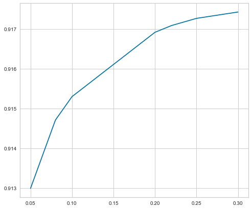

```python
# train
plt.figure(figsize=(8,7))
plt.plot(learning_rate, train, label='train')
plt.show();
```

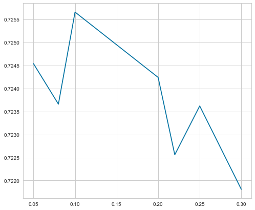

```python
# test
plt.figure(figsize=(8,7))
plt.plot(learning_rate, test, label = 'test')
plt.show();
```

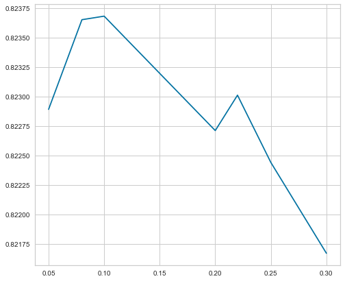

```python
# val
plt.figure(figsize=(8,7))
plt.plot(learning_rate, val, label='val')
plt.show();
```

> **more approximate proof that 0.10 is a good learning rate...**

### Experiment: Iterating over min_child_weight

> Iterating over min_child_weight (leveraring GPU speed) !

```python
print('Iterating over min_child_weight for understanding...')

start_time = time.time()

def QRF_i(df_train, df_val, df_test,model_features, incremental_min_cw):
    target = ['price_per_sq_m_per_lease_yr_norm']  # predict this !
    X_train =  df_train[model_features].copy()
    X_train = X_train.drop(columns = 'price_per_sq_m_per_lease_yr_norm')
    X_train = X_train.values
    X_test =  df_test[model_features].copy()
    X_test =  X_test.drop(columns = 'price_per_sq_m_per_lease_yr_norm')
    X_test = X_test.values
    X_val =  df_val[model_features].copy()
    X_val = X_val.drop(columns = 'price_per_sq_m_per_lease_yr_norm')
    X_val = X_val.values
    y_train =  df_train[target].values.ravel()
    y_val   =  df_val[target].values.ravel()
    y_test  =  df_test[target].values.ravel()

    # lock down everything but min_child_weight

    xg = xgb.XGBRegressor(

    objective='reg:squarederror',

    min_child_weight= incremental_min_cw,

    gamma = 8,

    subsample=0.5,  colsample_bytree = 0.5,

    # reg_alpha = 100,  reg_lambda = 1,  default for now

    max_depth=5,  # going to try 4 here for experimentation.
    #               later i will find out that 3 and 5 are pretty good.

    n_estimators=3000, learning_rate= 0.10,

    seed=42, tree_method='gpu_hist', gpu_id=0)

    print('min_child_weight .......', incremental_min_cw)

    xg.fit(X_train, y_train)
    y_pred_train =  xg.predict(X_train)
    y_pred_test  =  xg.predict(X_test)
    y_pred_val   =  xg.predict(X_val)

    print("Test R^2:...... %.5f" %  r2_score(y_test, y_pred_test))
    print("Val R^2:....... %.5f" %  r2_score(y_val, y_pred_val))
    print("Train R^2:..... %.5f" %  r2_score(y_train, y_pred_train))


for icw in [0, 1, 2, 3, 4, 5, 6, 7, 8, 9, 10]:
    QRF_i(df_train, df_val, df_test,features_to_use_from_MM, icw)

print("\n--- %s seconds ---" % round((time.time() - start_time)))
```

```
Iterating over min_child_weight for understanding...
min_child_weight ....... 0
Test R^2:...... 0.72121
Val R^2:....... 0.82265
Train R^2:..... 0.91793
min_child_weight ....... 1
Test R^2:...... 0.72121
Val R^2:....... 0.82265
Train R^2:..... 0.91793
min_child_weight ....... 2
Test R^2:...... 0.72392
Val R^2:....... 0.82262
Train R^2:..... 0.91781
min_child_weight ....... 3
Test R^2:...... 0.72172
Val R^2:....... 0.82256
Train R^2:..... 0.91758
min_child_weight ....... 4
Test R^2:...... 0.72426
Val R^2:....... 0.82304
Train R^2:..... 0.91745
min_child_weight ....... 5
Test R^2:...... 0.72151
Val R^2:....... 0.82317
Train R^2:..... 0.91730
min_child_weight ....... 6
Test R^2:...... 0.72373
Val R^2:....... 0.82286
Train R^2:..... 0.91727
min_child_weight ....... 7
Test R^2:...... 0.72253
Val R^2:....... 0.82260
Train R^2:..... 0.91713
min_child_weight ....... 8
Test R^2:...... 0.72616
Val R^2:....... 0.82261
Train R^2:..... 0.91702
min_child_weight ....... 9
Test R^2:...... 0.72325
Val R^2:....... 0.82284
Train R^2:..... 0.91696
min_child_weight ....... 10
Test R^2:...... 0.72354
Val R^2:....... 0.82261
Train R^2:..... 0.91688

--- 644 seconds ---
```

```python
# these are linear

min_child_weight = [0, 1, 2, 3, 4, 5, 6, 7, 8, 9, 10]


train = [0.91793,
0.91793,
0.91781,
0.91758,
0.91745,
0.91730,
0.91727,
0.91713,
0.91702,
0.91696,
0.91688]

test = [0.72121,
0.72121,
0.72392,
0.72172,
0.72426,
0.72151,
0.72373,
0.72253,
0.72616,
0.72325,
0.72354]

val = [0.82265,
0.82265,
0.82262,
0.82256,
0.82304,
0.82317,
0.82286,
0.82260,
0.82261,
0.82284,
0.82261]


df = pd.DataFrame(list(zip(min_child_weight, train, test, val)),
               columns =['min_child_weight', "train", "test", "val"])

df
```

|  | min_child_weight | train | test | val |
| --- | --- | --- | --- | --- |
| 0 | 0 | 0.91793 | 0.72121 | 0.82265 |
| 1 | 1 | 0.91793 | 0.72121 | 0.82265 |
| 2 | 2 | 0.91781 | 0.72392 | 0.82262 |
| 3 | 3 | 0.91758 | 0.72172 | 0.82256 |
| 4 | 4 | 0.91745 | 0.72426 | 0.82304 |
| 5 | 5 | 0.91730 | 0.72151 | 0.82317 |
| 6 | 6 | 0.91727 | 0.72373 | 0.82286 |
| 7 | 7 | 0.91713 | 0.72253 | 0.82260 |
| 8 | 8 | 0.91702 | 0.72616 | 0.82261 |
| 9 | 9 | 0.91696 | 0.72325 | 0.82284 |
| 10 | 10 | 0.91688 | 0.72354 | 0.82261 |

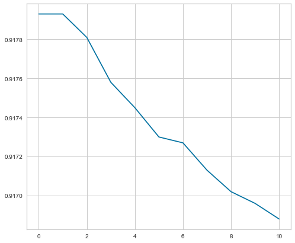

```python
# train
plt.figure(figsize=(8,7))
plt.plot(min_child_weight, train, label='train')
plt.show();
```

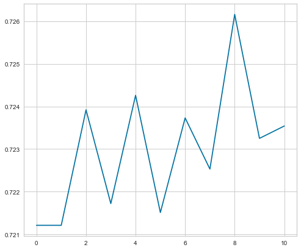

```python
# test
plt.figure(figsize=(8,7))
plt.plot(min_child_weight, test, label = 'test')
plt.show();
```

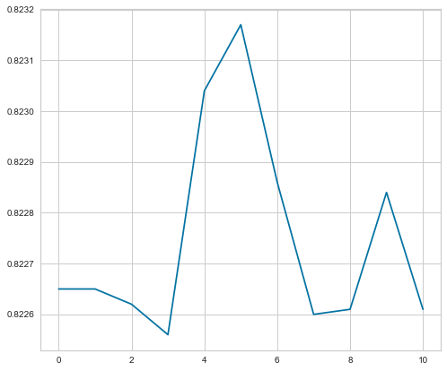

```python
# val
plt.figure(figsize=(8,7))
plt.plot(min_child_weight, val, label='val')
plt.show();
```

> high level, looks like min_child_weight may be in the arena from 5-8 ballpark...or possibly 4 fits both val and test use cases (compromise)